# Reproducible Research: Peer Assessment 1

This report is created using R markdown document and Knitr package using R studio. The solution for the various parts of the assignment is provided below.

## Loading and preprocessing the data

- Load the ggplot package. We will be using this for generating all graphs related to this assignment.
- Read the data from csv file and store it in a data frame

```r
library(ggplot2)
raw_data <- read.csv("activity.csv")
```

## What is mean total number of steps taken per day?

- `NA` values are omitted from the raw data set and total steps per day is calculated using the aggregate function
- mean and median values are calculated from the aggregated data set
- Graph created using ggplot with Date in x-axis and no. of steps in y-axis

```r
Clean_data <- na.omit(raw_data)

steps_per_day <- aggregate(steps ~ date, data = Clean_data, sum)

mean(steps_per_day$steps)
```

```
## [1] 10766.19
```

```r
median(steps_per_day$steps)
```

```
## [1] 10765
```

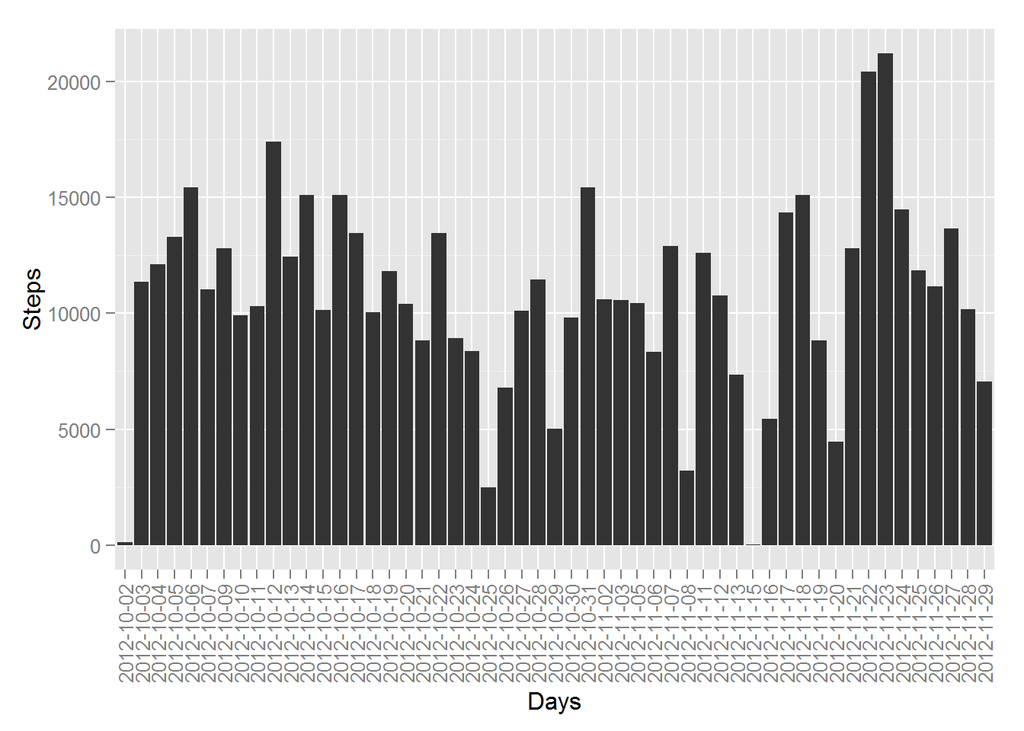

```r
ggplot(data = steps_per_day, aes(x = date, y = steps)) + geom_bar(stat =  "identity") + xlab("Days")+ylab("Steps")+theme(axis.text.x=element_text(angle=90,hjust=1,vjust=0.5))
```

## What is the average daily activity pattern?

- calculate the average number of steps per interval using the data set without `NA`
- Use ggplot to generate graph with interval in x-axis and steps in y-axis
- Identify the interval having max no. of steps from the data set created above

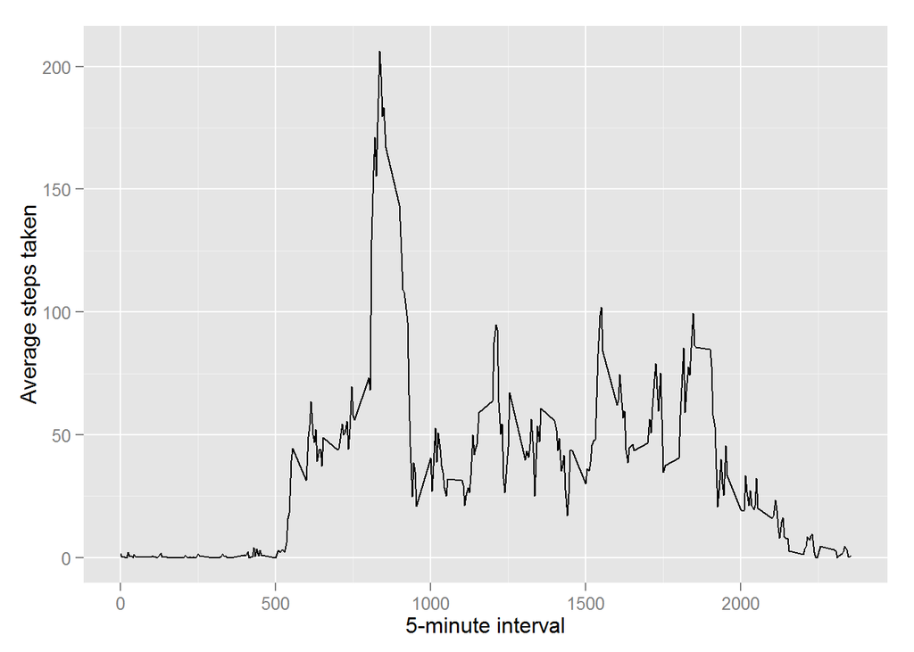

```r
Step_interval <- aggregate(steps ~ interval, data = Clean_data, mean)

ggplot(data=Step_interval, aes(x=interval, y=steps)) + geom_line() + xlab("5-minute interval") + ylab("Average steps taken")
```

```r
Step_interval[Step_interval$steps == max(Step_interval$steps),1]
```

```
## [1] 835
```

## Imputing missing values

- Create a new data frame and copy the data from raw_data
- Check the no. of instance having `NA` in the steps column
- Populate the `NA` instances for each day with mean no. of steps calculated for that day. If no mean value is available for a given day, populate zero for all `NA` instances on that day
- After completing above step, rerun the code to check the `NA` occurance. This should return zero

```r
Fill_NA <- raw_data

sum(is.na(Fill_NA))
```

```
## [1] 2304
```

```r
Step_Date <- aggregate(steps ~ date, data = raw_data, mean)

for (i in 1:nrow(Fill_NA)) {
      if (is.na(Fill_NA$steps[i])) {
            if(length(Step_Date[which(Fill_NA$date[i] == Step_Date$date),]$steps) == 0){
                  Fill_NA$steps[i] <- 0}
            else{
                  Fill_NA$steps[i] <- Step_Date[which(Fill_NA$date[i] == Step_Date$date),]$steps
            }
      }
}

sum(is.na(Fill_NA))
```

```
## [1] 0
```

```r
fill_steps_per_day <- aggregate(steps ~ date, data = Fill_NA, sum)

mean(fill_steps_per_day$steps)
```

```
## [1] 9354.23
```

```r
median(fill_steps_per_day$steps)
```

```
## [1] 10395
```

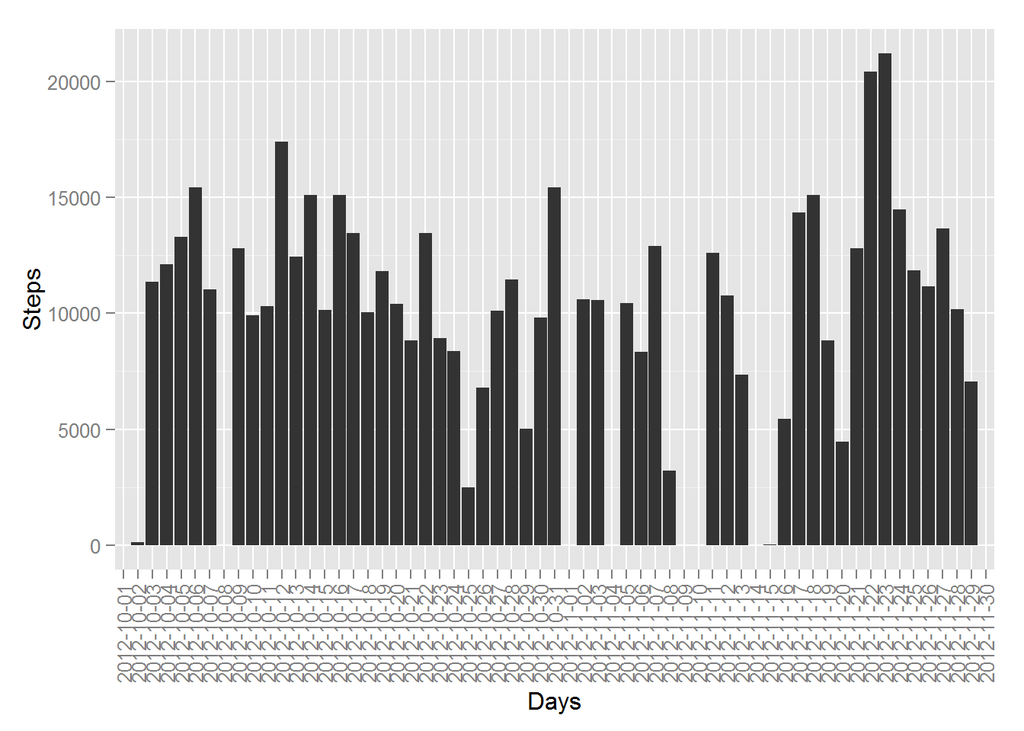

```r
ggplot(data = fill_steps_per_day, aes(x = date, y = steps)) + geom_bar(stat =  "identity") + xlab("Days")+ylab("Steps")+theme(axis.text.x=element_text(angle=90,hjust=1,vjust=0.5))
```

Comparing the mean and median for data set with `NA` values and after removing `NA` values, we can see that the mean and median have come down from the original value

## Are there differences in activity patterns between weekdays and weekends?

- Use the weekdays() function derive the day for each date in the data set
- Create a factor variable to group the days into weekends or weekdays
- Add the factor variable to the data frame
- Use ggplot to draw the graph with interval in x-axis and steps in y-axis. Use the daytype factor in facet_grid option to the split the steps across weekends/weekdays

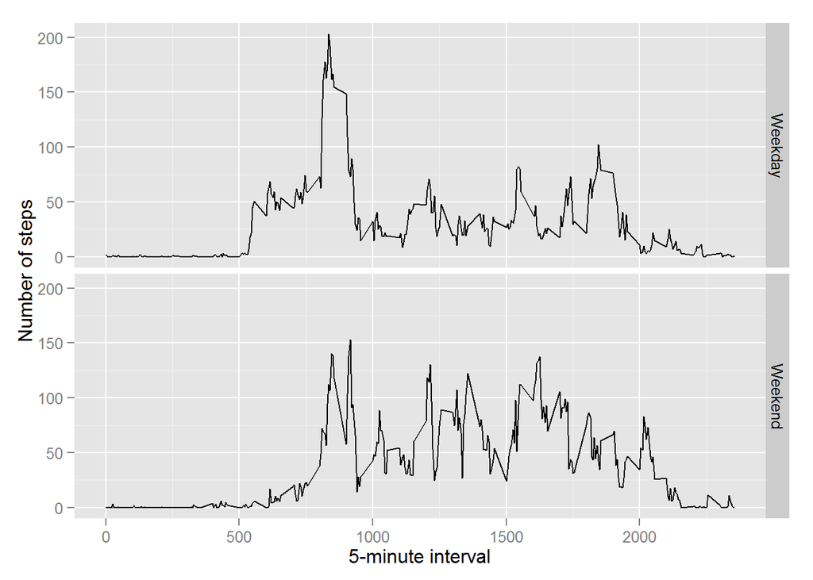

```r
Fill_NA$Days <- weekdays(as.Date(Fill_NA$date))

Fill_NA$DayType <- "NA"

for (i in 1:nrow(Fill_NA)) {
      if(Fill_NA$Days[i] %in% c("Saturday", "Sunday")) {Fill_NA$DayType[i] <- "Weekend"}
            else {Fill_NA$DayType[i] <- "Weekday"}
}

Fill_NA$DayTypeFac <- factor(Fill_NA$DayType, levels = c("Weekday", "Weekend"))

DayType_Data <- aggregate(steps ~ interval + DayType, data=Fill_NA, mean)

ggplot(data = DayType_Data, aes(x= interval, y=steps)) + geom_line() + facet_grid(DayType ~ .) + xlab("5-minute interval") + ylab("Number of steps")
```